# Lab 4: Do a teacher’s expectations influence student achievement?

Lei Qian and Rebecca C. Steorts

February 8, 2017

Let’s first load packages that we’ll need in this assignment and also load the data.

Teacher gives two tests to all the students data = difference in teh test scores objective: is there a difference in teh performance between ad S and C

`#S` = 20% of the class (random) `#C` = 80% of the class (random)

```r
# input data
x = c(18, 40, 15, 17, 20, 44, 38)
y = c(-4, 0, -19, 24, 19, 10, 5, 10,
      29, 13, -9, -8, 20, -1, 12, 21,
      -7, 14, 13, 20, 11, 16, 15, 27,
      23, 36, -33, 34, 13, 11, -19, 21,
      6, 25, 30,22, -28, 15, 26, -1, -2,
      43, 23, 22, 25, 16, 10, 29)
# store data in data frame
iqData = data.frame(
    Treatment = c(rep("Spurters", length(x)),
                  rep("Controls", length(y))),
    Gain = c(x, y))
head(iqData)
```

|  | Treatment | Gain |
| --- | --- | --- |
| 1 | Spurters | 18 |
| 2 | Spurters | 40 |
| 3 | Spurters | 15 |
| 4 | Spurters | 17 |
| 5 | Spurters | 20 |
| 6 | Spurters | 44 |

### Task 1

Plot histograms for the change in IQ score for the two groups. Report your findings.

an easy way is to use R base plot

```
1. hist(S)
2. hold on
3. hist(C)
```

```r
xLimits = seq(min(iqData$Gain) - (min(iqData$Gain) %% 5),
              max(iqData$Gain) + (max(iqData$Gain) %% 5),
              by = 5)
print(min(iqData$Gain))
```

```
## [1] -33
```

```r
print(min(iqData$Gain) %% 5) # ((-33) - r) %% 5 == 0 => r = 2
```

```
## [1] 2
```

```r
print(xLimits)
```

```
##  [1] -35 -30 -25 -20 -15 -10  -5   0   5  10  15  20  25  30  35  40  45
```

Note: notice that different treatment is plotted side by side instead of laying on top of each other.

here for each bin, it is plotting controls and spurters separately.

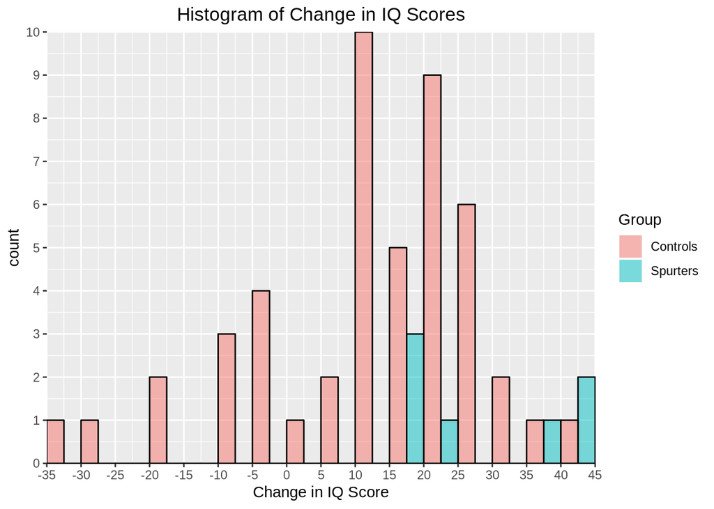

```r
### set up breaks of historgram with binwidth = 5
xLimits = seq(min(iqData$Gain) - (min(iqData$Gain) %% 5),
              max(iqData$Gain) + (max(iqData$Gain) %% 5),
              by = 5)

ggplot(data = iqData, aes(x = Gain, fill = Treatment, colour = I("black"))) +
    geom_histogram(position = "dodge",
                   alpha = 0.5,
                   breaks = xLimits,
                   closed = "left") +
  scale_x_continuous(breaks = xLimits,
                     expand = c(0,0))+
  scale_y_continuous(expand = c(0,0),
breaks = seq(0, 10, by = 1))+
  ggtitle("Histogram of Change in IQ Scores") + labs(x = "Change in IQ Score", fill = "Group") + theme(plot.title = element_text(hjust = 0.5))
```

From the histograms, I know that the randomly selected “spurters” group has a different distribution than the “controls” group. This could indicate that teachers being told that a specific group of students is expected to perform particularly well will pay more attention and time on that group and resulting in more improvement over the year.

### Task 2

likelihood

$$\begin{aligned}
p(X_1...X_{n_s}|\mu_s, \lambda_s^{-1}) &= \prod_{i=1}^{n_s} \frac{1}{\sqrt{2{\sigma_s}^2 \pi}} e^{-\frac{(x_i-{\mu_s})^2}{2{\sigma_s}^2}} = \prod_{i=1}^{n_s} \frac{1}{\sqrt{2{\lambda_s}^{-1} \pi}} e^{-\frac{{\lambda_s}(x_i-{\mu_s})^2}{2}} \\
p(Y_1...Y_{n_c}|\mu_c, \lambda_c^{-1}) &= \prod_{i=1}^{n_c} \frac{1}{\sqrt{2{\sigma_c}^2 \pi}} e^{-\frac{(y_i-{\mu_c})^2}{2{\sigma_c}^2}} = \prod_{i=1}^{n_c} \frac{1}{\sqrt{2{\lambda_c}^{-1} \pi}} e^{-\frac{{\lambda_c}(y_i-{\mu_c})^2}{2}} \\
p(\mu_s, \lambda_s|m,c,a,b) &= \frac{b^a \sqrt{c}}{\Gamma(a) \sqrt{2\pi}} \lambda_s^{a-0.5}e^{-b \lambda_s} e^{-\frac{c \lambda_s (\mu_s - m)^2}{2}} \\
p(\mu_c, \lambda_c|m,c,a,b) &= \frac{b^a \sqrt{c}}{\Gamma(a) \sqrt{2\pi}} \lambda_c^{a-0.5}e^{-b \lambda_c} e^{-\frac{c \lambda_c (\mu_c - m)^2}{2}} \\
(\mu_s, \lambda_s)|x_{1:n_s} \sim & \text{NormalGamma}\left(m' = \frac{cm + n_s\bar{x}}{c + n_s}, c' = c + n_s, a' = a + \frac{n_s}{2}, b' = b + \frac{1}{2}\sum_{i=1}^{n_s}(x_i - \bar{x})^2 + \frac{n_s c}{c + n_s}\frac{(\bar{x}-m)^2}{2}\right) \\
&= \text{NormalGamma}(24, 8, 4, 855) \\
(\mu_c, \lambda_c)|y_{1:n_c} \sim & \text{NormalGamma}\left(m^{*} = \frac{cm + n_c\bar{y}}{c + n_c}, c^{*} = c + n_c, a^{*} = a + \frac{n_c}{2}, b^{*} = b + \frac{1}{2}\sum_{i=1}^{n_c}(y_i - \bar{y})^2 + \frac{n_c c}{c + n_c}\frac{(\bar{y}-m)^2}{2}\right) \\
&= \text{NormalGamma}(11.8, 49, 24.5, 6344)
\end{aligned}$$

```r
prior = data.frame(m = 0, c = 1, a = 0.5, b = 50)
findParam = function(prior, data){
  postParam = NULL
  c = prior$c
  m = prior$m
  a = prior$a
  b = prior$b
  n = length(data)
  postParam = data.frame(m = (c*m + n*mean(data))/(c + n),
                c = c + n,
                a = a + n/2,
                b =  b + 0.5*(sum((data - mean(data))^2)) +
                  (n*c *(mean(data)- m)^2)/(2*(c+n)))
  return(postParam)
}
postS = findParam(prior, x)
postC = findParam(prior, y)
```

|  | m | c | a | b |
| --- | --- | --- | --- | --- |
| prior | 0.00000 | 1 | 0.5 | 50.00 |
| Spurters Posterior | 24.00000 | 8 | 4.0 | 855.00 |
| Controls Posterior | 11.79592 | 49 | 24.5 | 6343.98 |

### Task 3

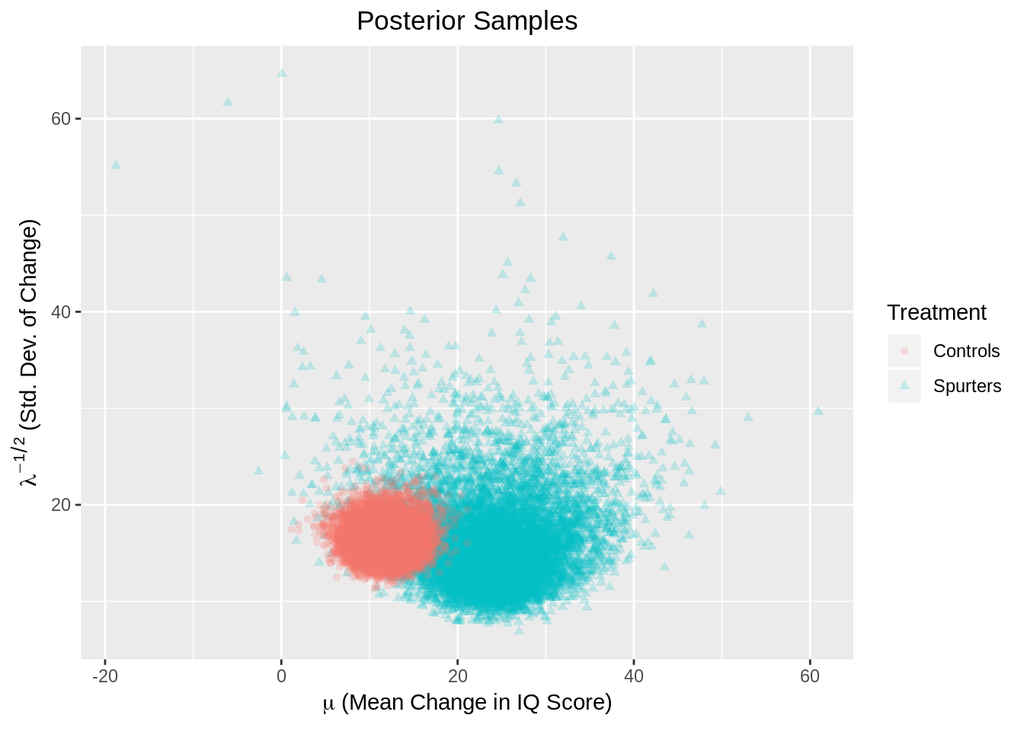

```r
# sampling from two posteriors

sim = 1e+4
# initialize vectors to store samples
mus = NULL
lambdas = NULL
muc = NULL
lambdac = NULL

lambdas = rgamma(sim, shape = postS$a, rate = postS$b)
lambdac = rgamma(sim, shape = postC$a, rate = postC$b)
mus = sapply(sqrt(1/(postS$c*lambdas)),rnorm, n = 1, mean = postS$m)
muc = sapply(sqrt(1/(postC$c*lambdac)),rnorm, n = 1, mean = postC$m)

simDF = data.frame(lambda = c(lambdas, lambdac),
                   mu = c(mus, muc),
                   Treatment = rep(c("Spurters", "Controls"),
                                   each = sim))
simDF$lambda = simDF$lambda^{-0.5}

ggplot(data = simDF, aes(x = mu, y = lambda, colour = Treatment, shape = Treatment)) +
  geom_point(alpha = 0.2) +
  labs(x = expression(paste(mu, " (Mean Change in IQ Score)")),
       y = expression(paste(lambda^{-1/2}, " (Std. Dev. of Change)")))  +
  ggtitle("Posterior Samples")+
  theme(plot.title = element_text(hjust = 0.5))
```